# 我的简历

简历 Rmarkdown HTML

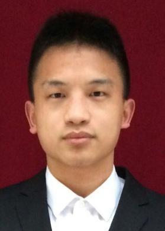

#### [Github主页](https://github.com/ZJUguquan) [Github博客](https://zjuguquan.github.io) [CSDN博客](http://blog.csdn.net/ZJUguquan/) [CodeWars主页](https://www.codewars.com/users/ZJUguquan) [在线简历地址](https://guquq.coding.me/homepage/Resume.html)

## 1. 基本信息

```
姓名：顾全                                                               年龄：27
毕业院校：浙江大学                                               邮箱：guquan92@zju.edu.cn
求职意向：数据挖掘/机器学习/算法                     手机：18667169865
```

## 2. 教育背景

[figure not shown]

### 本科

#### 2010.08至2014.06 浙江大学 公共管理 - 行政管理系 GPA：4.3 / 5 top 10%

> 主修课程：微积分、线性代数、概率论与数理统计、常微分方程、宏/微观经济学、人力资源开发与管理、管理学、会计学等

### 硕士

#### 2015.08至2018.03 浙江大学 软件工程 - 金融数据分析技术专业 GPA：4.6 / 5 top 5%

> 主修课程：机器学习与数据挖掘、Tensorflow/Keras深度学习实战、R语言及其应用、高级数据库与数据仓库、大数据处理和可视化、现代证券与金融市场、金融数据分析基础等

#### 硕士毕业论文：[《基于R语言的分布式机器学习平台设计与实现》](https://guquq.coding.me/homepage/pdf/QA.pdf)

## 3. 兴趣和能力

### 荣誉和获奖

#### 2018.06 第二届智慧中国杯（ICC）凤凰金融量化投资大赛，初赛排名：第四阶段，**1** / 911（冠军），B榜，**5** / 911，决赛排名：**2** / 20

#### 2017.12 京东金融全球数据探索者大赛 - 信贷需求预测算法赛，初赛排名：**11** / 755

#### 2017.09 阿里云天池 - 全国社会保险大数据应用创新大赛，初赛排名：**7** / 1336，决赛排名：**8** / 50，(A榜第5)

#### 2016.10 阿里云天池 - 机场客流量时空分布预测大赛，第一赛季排名：142 / 3038

#### 2014.06 被评为“浙江大学优秀毕业生”

#### 2013.10 获浙江大学年度学业优秀奖学金、“三好学生”和“优秀学生”荣誉称号

#### 2012.10 获浙江大学年度学业优秀奖学金、“三好学生”和“优秀学生”荣誉称号

### 个人开源项目

- [CTM](https://cran.r-project.org/web/packages/CTM/) ：一个R算法包，全称为 Chinese Text Mining，用作中文分词、统计语料库词频、生成文档词条矩阵（DTM）并计算TF-IDF值。
- OnlineRandomForest ：一个R算法包，译为在线随机森林，是随机森林算法的增量学习实现，同时支持批量或增量构建决策树和随机森林，使用R6面向对象的范式编写。

### 研究兴趣

这些是我**接触**过的知识…

[interactive chart not shown]

### 编程技能

一张图告诉你我的技能加点…  
假设满分是100分，那么我主要加过点的技能得分是…

[interactive chart not shown]

```
解释一下技能得分由来：
1，数据挖掘(Data Mining)方面：本人使用了Python四年，R语言三年，SQL一直在用。熟悉Python中的numpy、pandas，R中dplyr、data.table等数据挖掘工具包。

2，机器学习(Machine Learning)方面：擅长用R的Caret、Python的sklearn包。业余时间参加过多次机器学习竞赛，如Kaggle、阿里云天池、京东金融、DataCastle等平台的算法比赛，多次排名靠前（Top 10），在特征工程领域有比较丰富的经验。会用tensorflow和Keras进行深度学习建模，使用tensorflow实现过VggNet、LSTM、Seq2Seq等神经网络。

3，大数据(Big Data)方面：熟悉Spark分布式机制和RDD、DataFrame，会用PySpark、SparkR以及Sparklyr做机器学习，以及最近流行的Koloas；熟悉Hive、Hbase以及对应的python或R的接口（如RHive、SQLAlchemy）；了解Spark的PS框架SOna和Python分布式编程框架Dask。

4，前端开发(Web Development)方面：精通R的Shiny、Plumber以及Python的Flask的开发框架，写过不下10个应用；擅长数据可视化；Echarts也接触快两年了，能独立使用也能通过recharts使用；至于Web三件套HTML、JavaScript和CSS则学了有一年，能完成基本开发需求（这个简历就是通过Rmarkdown+JQuery+CSS写的）。
```

我在工作中用到的主要技能占比…

[interactive chart not shown]

## 4. 工作经验

### 工作经历

#### 2018.07 - 至今，同盾科技有限公司，任资深算法工程师

#### 机器学习平台部门，职级 P6

#### 荣获“季度之星”， 2018年度绩效为 3.75 ， 部门唯一一个

```
主导/参与过的项目（按时间倒序，鼠标悬浮可查看详情）：
1，同盾科技自动化机器学习（AutoML）项目：Owner
2，同盾新一代分布式机器学习框架（Pandora）开发：Owner
3，分布式深度学习训练框架（xtrain）开发：Owner
4，同盾天机机器学习平台（enki）开发：负责多个分布式算法/算子的开发以及全部算子的迁移工作
5，算法性能优化工作：多次为公司内部建模人员优化算法代码
6，北京民生银行贷前反欺诈POC建模项目：开发有监督算法、无监督关联规则、以及欺诈网络可视化
7，合作方时间序列异常检测（mokona-ml，同盾第一个无监督算法应用）：算法Owner
```

#### 2017.04 - 2018.07，杭州量知数据科技有限公司，任算法工程师

#### 兼任数据挖掘组负责人，组员8人，汇报对象为CEO

#### 荣获“月度之星”/“月度优秀员工”， 2017年度绩效为 A (Top 10%)

```
主导/参与过的项目（按时间倒序，鼠标悬浮可查看详情）：
1，自动化机器学习（Atom）在线部署：Owner
2，量化交易引擎（Meek）开发：负责数据处理代码优化
3，时间序列相似性算法开发：Owner
4，机器学习平台开发：Owner
5，财通证券两融潜在客户挖掘：负责机器学习建模
6，财通证券客户画像构建：负责指标/标签设计及代码实现
7，智能取数：负责使用LSTM进行语义建模
```

#### 2016.05 - 2017.04，北京网思科平科技有限公司，任机器学习工程师

```
参与过的项目（按时间倒序，鼠标悬浮可查看详情）：
1，微博计算项目：负责数据处理、可视化、前端展示
2，精准营销DMP项目：负责文本挖掘、机器学习建模
3，绍兴公安大数据项目：负责机器学习、可视化
```

### 在校项目经验:

#### 以下是我在校期间的个人项目，欢迎访问（都是三年前做的，long time ago，彼时技能还较生疏）…

```
1，Kaggle数据挖掘竞赛1，应用逻辑回归和WOE变换帮助银行建立信用评分卡，项目demo链接
2，Kaggle数据挖掘竞赛2，利用随机森林等组合算法对Titanic项目做逃生预测，项目demo链接
3，Kaggle数据挖掘竞赛3，利用Amazon公司员工的职位信息去预测员工的资源索取权限，项目demo链接
4，Kaggle数据挖掘竞赛4，利用特征工程和机器学习完成手写数字识别项目，项目demo链接
5，Kaggle数据挖掘竞赛5，利用文本挖掘方法实现社交评论中的脏话识别，项目demo链接
6，手撸Python代码，用随机梯度下降算法实现Logistic Regression模型，项目demo链接
7，微整形数据可视化项目，项目demo链接1，链接2，链接3
8，利用二叉树和Black-Scholes公式预测期权价格，以及实现BS公式的数学推导，项目demo链接
9，利用SVD奇异值分解预测用户对电影的评分，并进行大规模电影推荐等
```

## 5. 自我评价

- 具有很强的理科逻辑思维能力（尽管本科学的管理学），大学之前为理科生，曾依次获得国际奥数金牌、物理国家一等奖、数/理/化省级一等奖
- 有扎实的机器学习算法基础，工程能力较强，擅长阅读前沿理论paper并进行代码复现，擅长建模
- 持续保持高强度的学习能力、执行力和自驱力，从业三年多以来工作从未逾期并一直保持高绩效/产出